# Data Visualization

Alan Ponce  
2022-07-26

[figure not shown]

## Agenda

- Quick recap
  - Tidyyverse
  - Importing data
  - Cleaning data
- Data Visualization
- Conclusions
- Q&A

## R Base: Visualization

### base package and ggplot2, part 1 - plot

```r
head(mtcars)
```

```
                   mpg cyl disp  hp drat    wt  qsec vs am gear carb
Mazda RX4         21.0   6  160 110 3.90 2.620 16.46  0  1    4    4
Mazda RX4 Wag     21.0   6  160 110 3.90 2.875 17.02  0  1    4    4
Datsun 710        22.8   4  108  93 3.85 2.320 18.61  1  1    4    1
Hornet 4 Drive    21.4   6  258 110 3.08 3.215 19.44  1  0    3    1
Hornet Sportabout 18.7   8  360 175 3.15 3.440 17.02  0  0    3    2
Valiant           18.1   6  225 105 2.76 3.460 20.22  1  0    3    1
```

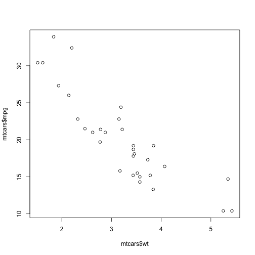

```r
# Plot the correct variables of mtcars
plot(mtcars$wt, mtcars$mpg)
```

### base package and ggplot2, part 1 - plot

```r
str(mtcars)
```

```
'data.frame':   32 obs. of  11 variables:
 $ mpg : num  21 21 22.8 21.4 18.7 18.1 14.3 24.4 22.8 19.2 ...
 $ cyl : num  6 6 4 6 8 6 8 4 4 6 ...
 $ disp: num  160 160 108 258 360 ...
 $ hp  : num  110 110 93 110 175 105 245 62 95 123 ...
 $ drat: num  3.9 3.9 3.85 3.08 3.15 2.76 3.21 3.69 3.92 3.92 ...
 $ wt  : num  2.62 2.88 2.32 3.21 3.44 ...
 $ qsec: num  16.5 17 18.6 19.4 17 ...
 $ vs  : num  0 0 1 1 0 1 0 1 1 1 ...
 $ am  : num  1 1 1 0 0 0 0 0 0 0 ...
 $ gear: num  4 4 4 3 3 3 3 4 4 4 ...
 $ carb: num  4 4 1 1 2 1 4 2 2 4 ...
```

```r
# Change cyl inside mtcars to a factor
mtcars$fcyl <- as.factor(mtcars$cyl)
```

### base package and ggplot2, part 1 - plot

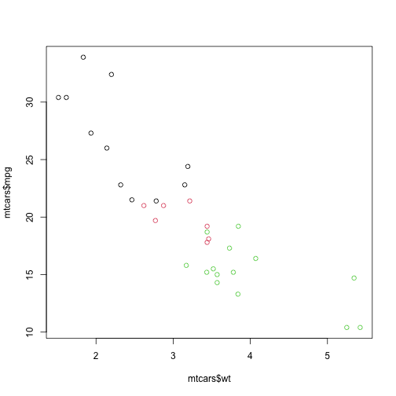

```r
# Make the same plot as in the first instruction but using a factor variable
plot(mtcars$wt, mtcars$mpg, col = mtcars$fcyl)
```

### base package and ggplot2

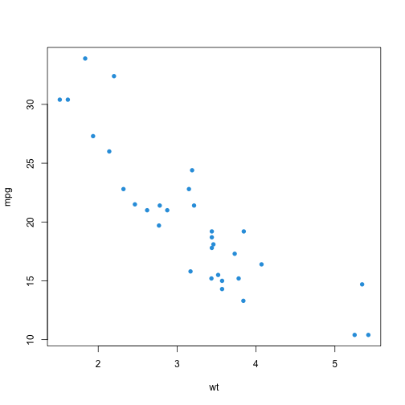

```r
plot(x = mtcars$wt, y = mtcars$mpg,
     pch = 16, frame = TRUE,
     xlab = "wt", ylab = "mpg", col = "#2E9FDF")
```

### base package and ggplot2

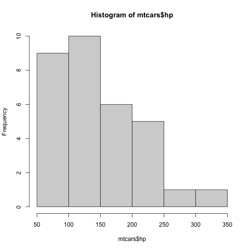

```r
hist(mtcars$hp)
```

### base package and ggplot2

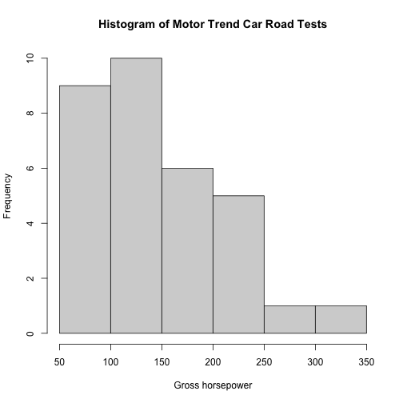

```r
hist(mtcars$hp,,
     xlab = "Gross horsepower",
     main = "Histogram of Motor Trend Car Road Tests",
     ylim = c(0,10))
```

### base package and ggplot2

```r
head(iris)
```

```
  Sepal.Length Sepal.Width Petal.Length Petal.Width Species
1          5.1         3.5          1.4         0.2  setosa
2          4.9         3.0          1.4         0.2  setosa
3          4.7         3.2          1.3         0.2  setosa
4          4.6         3.1          1.5         0.2  setosa
5          5.0         3.6          1.4         0.2  setosa
6          5.4         3.9          1.7         0.4  setosa
```

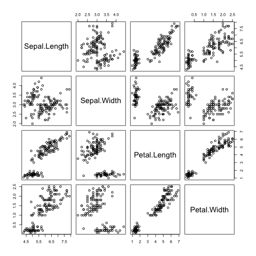

```r
pairs(iris[1:4])
```

### base package and ggplot2

```r
head(iris)
```

```
  Sepal.Length Sepal.Width Petal.Length Petal.Width Species
1          5.1         3.5          1.4         0.2  setosa
2          4.9         3.0          1.4         0.2  setosa
3          4.7         3.2          1.3         0.2  setosa
4          4.6         3.1          1.5         0.2  setosa
5          5.0         3.6          1.4         0.2  setosa
6          5.4         3.9          1.7         0.4  setosa
```

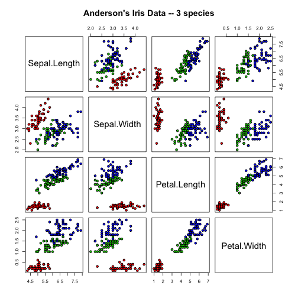

```r
pairs(iris[1:4], main = "Anderson's Iris Data -- 3 species",
      pch = 21, bg = c("red", "green3", "blue")[unclass(iris$Species)])
```

### base package and ggplot2

```r
head(iris)
```

```
  Sepal.Length Sepal.Width Petal.Length Petal.Width Species
1          5.1         3.5          1.4         0.2  setosa
2          4.9         3.0          1.4         0.2  setosa
3          4.7         3.2          1.3         0.2  setosa
4          4.6         3.1          1.5         0.2  setosa
5          5.0         3.6          1.4         0.2  setosa
6          5.4         3.9          1.7         0.4  setosa
```

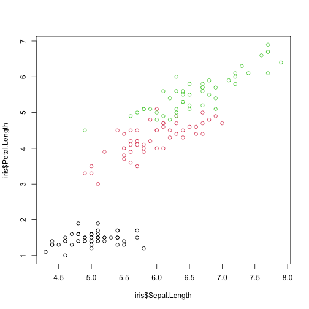

```r
plot(iris$Sepal.Length, iris$Petal.Length, col = iris$Species)
```

### base package and ggplot2

```r
head(iris)
```

```
  Sepal.Length Sepal.Width Petal.Length Petal.Width Species
1          5.1         3.5          1.4         0.2  setosa
2          4.9         3.0          1.4         0.2  setosa
3          4.7         3.2          1.3         0.2  setosa
4          4.6         3.1          1.5         0.2  setosa
5          5.0         3.6          1.4         0.2  setosa
6          5.4         3.9          1.7         0.4  setosa
```

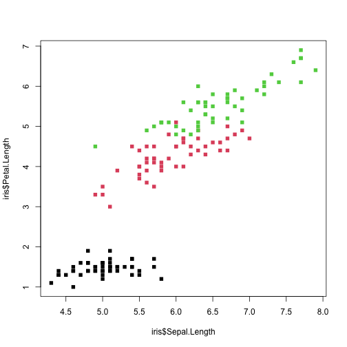

```r
plot(iris$Sepal.Length, iris$Petal.Length, col = iris$Species, pch = 15)
```

### base package and ggplot2

```r
head(iris)
```

```
  Sepal.Length Sepal.Width Petal.Length Petal.Width Species
1          5.1         3.5          1.4         0.2  setosa
2          4.9         3.0          1.4         0.2  setosa
3          4.7         3.2          1.3         0.2  setosa
4          4.6         3.1          1.5         0.2  setosa
5          5.0         3.6          1.4         0.2  setosa
6          5.4         3.9          1.7         0.4  setosa
```

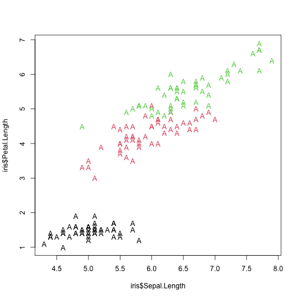

```r
plot(iris$Sepal.Length, iris$Petal.Length, col = iris$Species, pch = "A")
```

### base package and ggplot2

pch 21:25 also specify an edge colour (col) and a background colour (bg)

```r
head(iris)
```

```
  Sepal.Length Sepal.Width Petal.Length Petal.Width Species
1          5.1         3.5          1.4         0.2  setosa
2          4.9         3.0          1.4         0.2  setosa
3          4.7         3.2          1.3         0.2  setosa
4          4.6         3.1          1.5         0.2  setosa
5          5.0         3.6          1.4         0.2  setosa
6          5.4         3.9          1.7         0.4  setosa
```

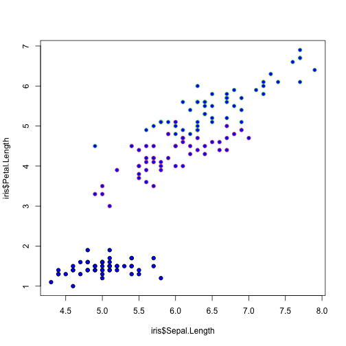

```r
plot(iris$Sepal.Length, iris$Petal.Length, col = iris$Species, pch = 21, bg = "blue")
```

### base package and ggplot2

lets settle on solid circles (pch = 16)

```r
head(iris)
```

```
  Sepal.Length Sepal.Width Petal.Length Petal.Width Species
1          5.1         3.5          1.4         0.2  setosa
2          4.9         3.0          1.4         0.2  setosa
3          4.7         3.2          1.3         0.2  setosa
4          4.6         3.1          1.5         0.2  setosa
5          5.0         3.6          1.4         0.2  setosa
6          5.4         3.9          1.7         0.4  setosa
```

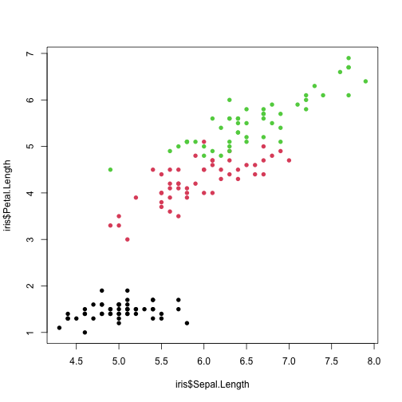

```r
plot(iris$Sepal.Length, iris$Petal.Length, col = iris$Species, pch = 16)
```

### base package and ggplot2

We can change the size of the points with “cex”

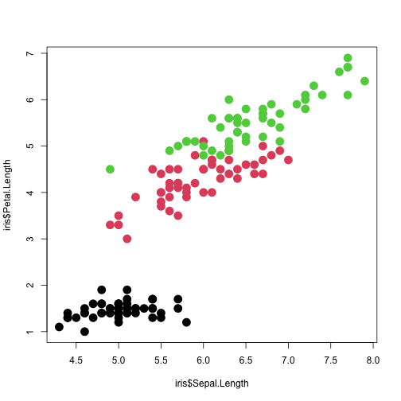

```r
plot(iris$Sepal.Length, iris$Petal.Length,
     col = iris$Species,
     pch = 16,
     cex = 2)
```

### base package and ggplot2

- Barplot

```r
head(mtcars)
```

```
                   mpg cyl disp  hp drat    wt  qsec vs am gear carb fcyl
Mazda RX4         21.0   6  160 110 3.90 2.620 16.46  0  1    4    4    6
Mazda RX4 Wag     21.0   6  160 110 3.90 2.875 17.02  0  1    4    4    6
Datsun 710        22.8   4  108  93 3.85 2.320 18.61  1  1    4    1    4
Hornet 4 Drive    21.4   6  258 110 3.08 3.215 19.44  1  0    3    1    6
Hornet Sportabout 18.7   8  360 175 3.15 3.440 17.02  0  0    3    2    8
Valiant           18.1   6  225 105 2.76 3.460 20.22  1  0    3    1    6
```

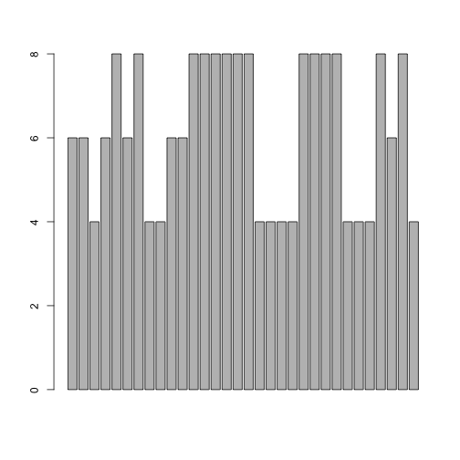

```r
barplot(mtcars$cyl)
```

### base package and ggplot2

- Barplot

```r
dragons <- data.frame(
  TalonLength = c(20.9, 58.3, 35.5),
  SE = c(4.5, 6.3, 5.5),
  Population = c("England", "Scotland", "Wales"))

dragons
```

```
  TalonLength  SE Population
1        20.9 4.5    England
2        58.3 6.3   Scotland
3        35.5 5.5      Wales
```

### base package and ggplot2

- Barplot

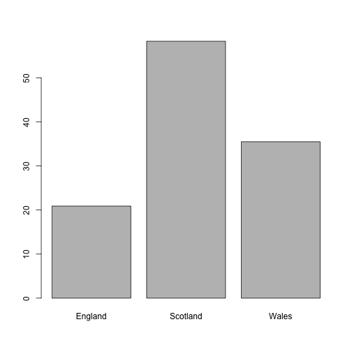

```r
barplot(dragons$TalonLength, names = dragons$Population)
```

### base package and ggplot2

- Barplot

```r
head(VADeaths)
```

```
      Rural Male Rural Female Urban Male Urban Female
50-54       11.7          8.7       15.4          8.4
55-59       18.1         11.7       24.3         13.6
60-64       26.9         20.3       37.0         19.3
65-69       41.0         30.9       54.6         35.1
70-74       66.0         54.3       71.1         50.0
```

```r
# Subset
x <- VADeaths[1:3, "Rural Male"]
x
```

```
50-54 55-59 60-64
 11.7  18.1  26.9
```

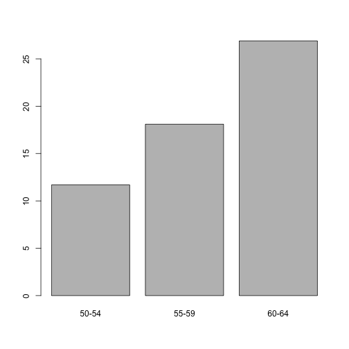

```r
# Bar plot of one variable
barplot(x)
```

### base package and ggplot2

- Barplot

```r
head(x)
```

```
50-54 55-59 60-64
 11.7  18.1  26.9
```

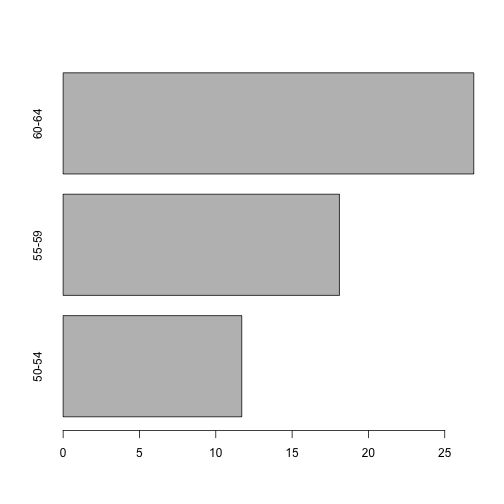

```r
# Horizontal bar plot
barplot(x, horiz = TRUE)
```

### base package and ggplot2

- Barplot

```r
head(x)
```

```
50-54 55-59 60-64
 11.7  18.1  26.9
```

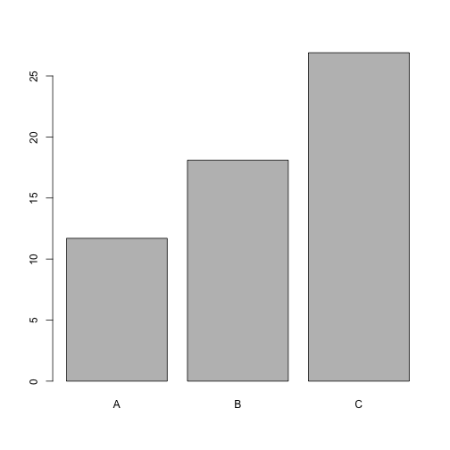

```r
# Change group names
barplot(x, names.arg = c("A", "B", "C"))
```

### base package and ggplot2

- Barplot

```r
head(x)
```

```
50-54 55-59 60-64
 11.7  18.1  26.9
```

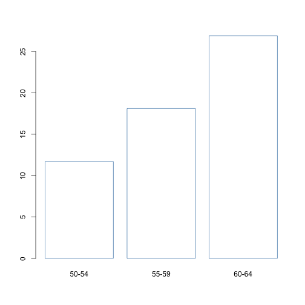

```r
# Change color
# Change border and fill color using one single color
barplot(x, col = "white", border = "steelblue")
```

### base package and ggplot2

- Barplot

```r
head(x)
```

```
50-54 55-59 60-64
 11.7  18.1  26.9
```

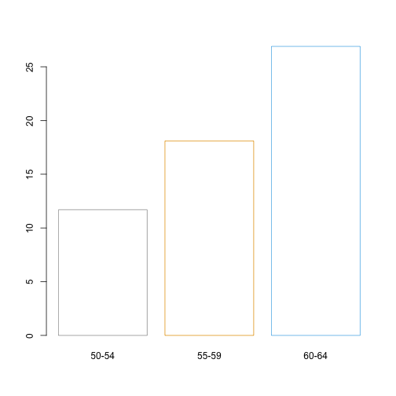

```r
# Change the color of border.
#  Use different colors for each group
barplot(x, col = "white",
        border = c("#999999", "#E69F00", "#56B4E9"))
```

### base package and ggplot2

- Barplot

```r
head(x)
```

```
50-54 55-59 60-64
 11.7  18.1  26.9
```

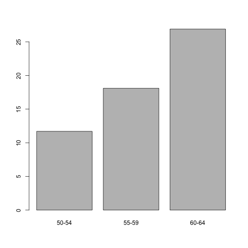

```r
# Change fill color : single color
barplot(x)
```

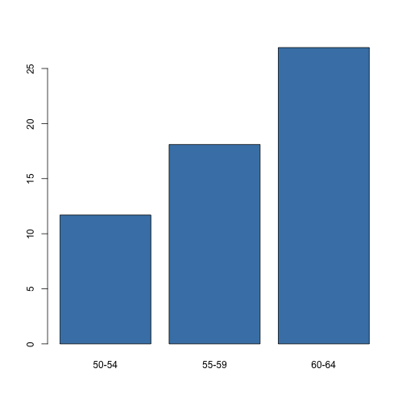

```r
barplot(x, col = "steelblue")
```

### base package and ggplot2

- Barplot

```r
head(x)
```

```
50-54 55-59 60-64
 11.7  18.1  26.9
```

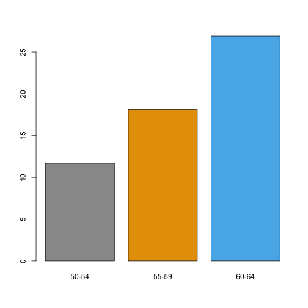

```r
# Change fill color: multiple colors
barplot(x, col = c("#999999", "#E69F00", "#56B4E9"))
```

### base package and ggplot2

- Barplot

```r
# Change main title and axis labels

head(x)
```

```
50-54 55-59 60-64
 11.7  18.1  26.9
```

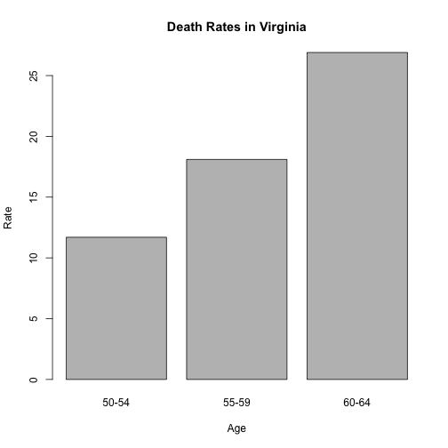

```r
# Change color (col = "gray") and remove frame
barplot(x, main = "Death Rates in Virginia",
        xlab = "Age", ylab = "Rate")
```

### base package and ggplot2

- Stacked bar plots

```r
# Change main title and axis labels

head(VADeaths)
```

```
      Rural Male Rural Female Urban Male Urban Female
50-54       11.7          8.7       15.4          8.4
55-59       18.1         11.7       24.3         13.6
60-64       26.9         20.3       37.0         19.3
65-69       41.0         30.9       54.6         35.1
70-74       66.0         54.3       71.1         50.0
```

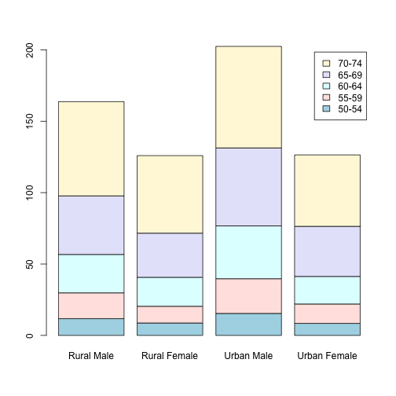

```r
barplot(VADeaths,
         col = c("lightblue", "mistyrose", "lightcyan",
                 "lavender", "cornsilk"),
        legend = rownames(VADeaths))
```

### base package and ggplot2

- Grouped bar plots

```r
# Change main title and axis labels

head(VADeaths)
```

```
      Rural Male Rural Female Urban Male Urban Female
50-54       11.7          8.7       15.4          8.4
55-59       18.1         11.7       24.3         13.6
60-64       26.9         20.3       37.0         19.3
65-69       41.0         30.9       54.6         35.1
70-74       66.0         54.3       71.1         50.0
```

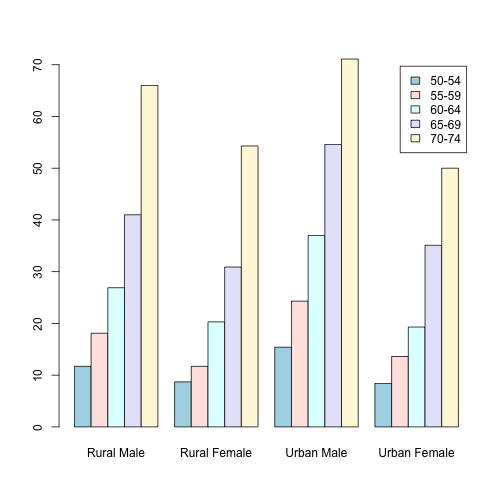

```r
barplot(VADeaths,
         col = c("lightblue", "mistyrose", "lightcyan",
                 "lavender", "cornsilk"),
        legend = rownames(VADeaths), beside = TRUE)
```

### base package and ggplot2

- Grouped bar plots

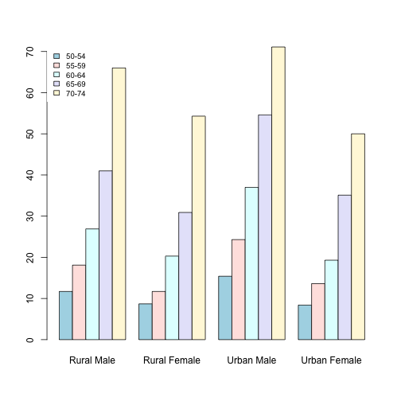

```r
#Run all chunck code

# Define a set of colors
my_colors <- c("lightblue", "mistyrose", "lightcyan",
                 "lavender", "cornsilk")
# Bar plot
barplot(VADeaths, col = my_colors, beside = TRUE)

# Add legend
legend("topleft", legend = rownames(VADeaths),
       fill = my_colors, box.lty = 0, cex = 0.8
       )
```

## Ggplot

- The Grammar of Graphics
- https://www.springer.com/gp/book/9780387245447

### Aesthetics

Aesthetic mappings are the cornerstone of the grammar of graphics plotting concept. This is where the magic happens - converting continuous and categorical data into visual scales that provide access to a large amount of information in a very short time

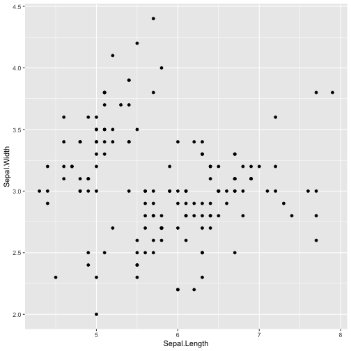

```r
ggplot(iris,
       aes(x = Sepal.Length, y = Sepal.Width)) +
        geom_point()
```

### Aesthetics

These are the aesthetics you can consider within aes() in this chapter: x, y, color, fill, size, alpha, labels and shape.

```r
head(mtcars)
```

```
                   mpg cyl disp  hp drat    wt  qsec vs am gear carb fcyl
Mazda RX4         21.0   6  160 110 3.90 2.620 16.46  0  1    4    4    6
Mazda RX4 Wag     21.0   6  160 110 3.90 2.875 17.02  0  1    4    4    6
Datsun 710        22.8   4  108  93 3.85 2.320 18.61  1  1    4    1    4
Hornet 4 Drive    21.4   6  258 110 3.08 3.215 19.44  1  0    3    1    6
Hornet Sportabout 18.7   8  360 175 3.15 3.440 17.02  0  0    3    2    8
Valiant           18.1   6  225 105 2.76 3.460 20.22  1  0    3    1    6
```

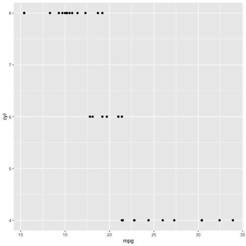

```r
# 1 - Map mpg to x and cyl to y
ggplot(mtcars, aes(x = mpg, y = cyl)) +
  geom_point()
```

### Aesthetics

These are the aesthetics you can consider within aes() in this chapter: x, y, color, fill, size, alpha, labels and shape.

```r
head(mtcars)
```

```
                   mpg cyl disp  hp drat    wt  qsec vs am gear carb fcyl
Mazda RX4         21.0   6  160 110 3.90 2.620 16.46  0  1    4    4    6
Mazda RX4 Wag     21.0   6  160 110 3.90 2.875 17.02  0  1    4    4    6
Datsun 710        22.8   4  108  93 3.85 2.320 18.61  1  1    4    1    4
Hornet 4 Drive    21.4   6  258 110 3.08 3.215 19.44  1  0    3    1    6
Hornet Sportabout 18.7   8  360 175 3.15 3.440 17.02  0  0    3    2    8
Valiant           18.1   6  225 105 2.76 3.460 20.22  1  0    3    1    6
```

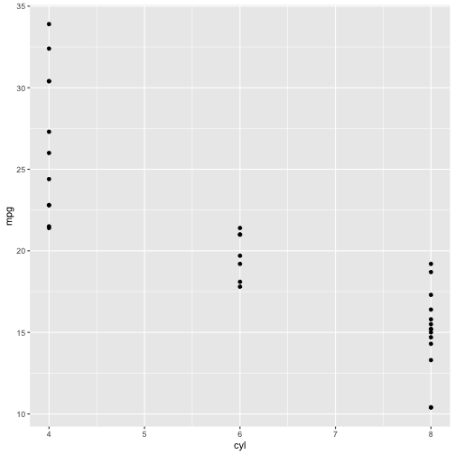

```r
# 2 - Reverse: Map cyl to x and mpg to y
ggplot(mtcars, aes(x = cyl, y = mpg)) +
  geom_point()
```

### Aesthetics

These are the aesthetics you can consider within aes() in this chapter: x, y, color, fill, size, alpha, labels and shape.

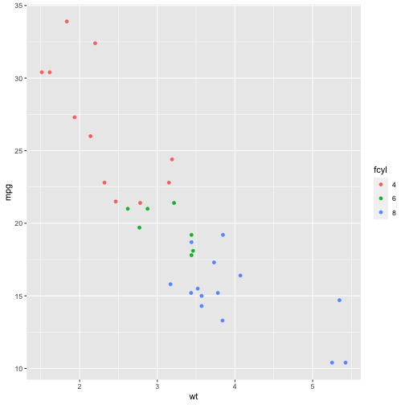

```r
# Change cyl inside mtcars to a factor
mtcars$fcyl <- as.factor(mtcars$cyl)

# 3 - Map wt to x, mpg to y and cyl to col
ggplot(mtcars, aes(x = wt, y = mpg, col = fcyl)) +
  geom_point()
```